# Package brms ‘tutorial’ for Bayes Group

Ellen Brandell

June 2021

# Background

This is a document for the Mastering Bayes working group, as a simple starting guide for using the package **brms** for Bayesian modeling. This tutorial is by no means extensive, but rather how I have found **brms** useful (or not) in the last month of working with it.

### Pros

1. easy and familiar implementation - writing models is similar to **lme4**
2. automated plotting functions that make nice outputs
3. nice online user guides and examples
4. **brms** tends to give you detailed warnings instead of errors, which provides you with information you need without voiding your model

Overall, it is an easy process from start to finish including model construction, running MCMC, error/warning checking, assessing outputs, and making plots. I did not plan to talk about this, but you actually can use **brms** plotting functions for other packages such as **nimble**, but need to manipulate the posterior samples, which can add some complications but is really handy.

### Cons

**brms** relies more on default settings than packages like **rjags** or **nimble**. In some ways, this makes **brms** easier to work with, but I believe this can be more harmful than helpful for the following reasons:

1. more of a ‘black box’ - you don’t see the full model structure and don’t need to write anything out in detail, which I see as a con because you may construct a model that is inappropriate or not functioning the way you intend it to
2. trickier to change priors and samplers
3. much less adaptable for complex models
4. parameter names are set within the **brms** model and can’t be changed, just an annoyance

Based on these lists, I find **brms** very nice for preliminary modeling or for more simple, glmm type of models.

### Other information + links

- **brms** uses Stan for Bayesian modeling and running MCMC
- CRAN manual: https://cran.r-project.org/web/packages/brms/brms.pdf
- https://www.rensvandeschoot.com/tutorials/generalised-linear-models-with-brms/
- http://mjskay.github.io/tidybayes/articles/tidy-brms.html  
  and lots, lots more!

# Getting started

This document and the some of the data are available in my GitHub repository: wolf_parasitology (link: https://github.com/EllenBrandell/wolf_parasitology). We need a few libraries:

```r
## load libraries for analysis
library(brms) # Bayesian model
```

```r
# library(sjstats) # calculate intra-class correlation (ICC), we don't use this here
library(tidybayes) # for analysis of posterior draws of a Bayesian model
## load libraries for plotting
library(tidyverse)
library(viridis)
library(cowplot)
library(bayesplot) # for plotting posterior draws of a Bayesian model
```

*Please do not share this document or data* but feel free to download this tutorial to your computer to mess around. These data are unpublished (in the works!) and not in a fully usable form. If you would like the full dataset I used here, please reach out.

## Project background

In brief, in this project, I have two aims that involve using **brms**:  
1. Examine the associations between wolf endoparasite infections and wolf social and biological characteristics;  
2. Examine how noninvasively-collected wolf samples were affected by environmental conditions with respect to the success of wolf genotyping.  
Wolf scat samples were collected and analyzed for parasites, stress, and wolves and parasites (cestodes) were both genotyped. *See more in the Read Me file in the GitHub repository.*

Here we are just going to be looking at goal #2. The response variable is *genotyping success*, a binary variable indicating whether or not a wolf scat sample was successfully genotyped to individual (0=unsuccessful / 1=successful). The explanatory variables are environmental variables known to influence host DNA quality and amplification efficacy: temperature, exposure to UV radiation, precipitation, time from deposit to collection, sampling period, and a random effect for site (i.e., multiple scats could be collected at one site).

### Load the data

```r
setwd("~/Desktop/scat_project/DATA/data_summaries")
success <- read.csv("sent_successful.csv") # indicates which samples were successfully genotyped
success <- success[,c(1,8)] # just need scatID and geno success information
meta <- read.csv("scat_metadata.csv") # environmental data
# combine data
data <- merge(success, meta, all.x=T, by="scatID")
```

Clean the data and take a look:

```r
# remove those without meta
data <- data[complete.cases(data),]
data <- data %>% mutate_at(vars("scatID","cover","period","site"), as.factor)
# cover 0:open, 1:covered.
data <- data %>% mutate_at(vars("geno","days_elapsed","high_temp_mean","total_precip"), as.numeric)
# make sure there is not missing data
summary(is.na(data))
```

```
##    scatID           geno           cover           period
##  Mode :logical   Mode :logical   Mode :logical   Mode :logical
##  FALSE:107       FALSE:107       FALSE:107       FALSE:107
##  days_elapsed    month_created   high_temp_mean  total_precip
##  Mode :logical   Mode :logical   Mode :logical   Mode :logical
##  FALSE:107       FALSE:107       FALSE:107       FALSE:107
##     site
##  Mode :logical
##  FALSE:107
```

```r
str(data)
```

```
## 'data.frame':    107 obs. of  9 variables:
##  $ scatID        : Factor w/ 107 levels "1","2","3","4",..: 1 2 3 4 5 6 7 8 9 10 ...
##  $ geno          : num  0 0 0 1 0 1 1 0 0 0 ...
##  $ cover         : Factor w/ 2 levels "0","1": 1 1 1 1 2 2 2 2 2 2 ...
##  $ period        : Factor w/ 3 levels "summer","winter",..: 1 1 1 1 1 1 1 1 1 1 ...
##  $ days_elapsed  : num  7 7 7 7 9 9 9 9 9 9 ...
##  $ month_created : chr  "August" "August" "August" "August" ...
##  $ high_temp_mean: num  70.4 70.4 70.4 70.4 70.7 ...
##  $ total_precip  : num  0.52 0.52 0.52 0.52 0.52 0.52 0.52 0.52 0.52 0.52 ...
##  $ site          : Factor w/ 38 levels "1","2","3","4",..: 1 1 1 1 2 2 2 2 2 2 ...
```

```r
summary(data)
```

```
##      scatID         geno        cover     period    days_elapsed
##  1      :  1   Min.   :0.0000   0:36   summer:22   Min.   : 1.00
##  2      :  1   1st Qu.:0.0000   1:71   winter:46   1st Qu.: 6.00
##  3      :  1   Median :0.0000          z_den :39   Median : 9.00
##  4      :  1   Mean   :0.4486                      Mean   :17.22
##  5      :  1   3rd Qu.:1.0000                      3rd Qu.:27.00
##  6      :  1   Max.   :1.0000                      Max.   :75.00
##  (Other):101
##  month_created      high_temp_mean   total_precip         site
##  Length:107         Min.   :16.08   Min.   :0.0100   66     :11
##  Class :character   1st Qu.:30.72   1st Qu.:0.0750   21     :10
##  Mode  :character   Median :65.05   Median :0.5200   46     :10
##                     Mean   :52.98   Mean   :0.6842   48     : 9
##                     3rd Qu.:71.76   3rd Qu.:1.3850   2      : 8
##                     Max.   :77.45   Max.   :2.8100   26     : 8
##                                                      (Other):51
```

# Construct and run model

## Using defaults

```r
model <- brm(formula= geno ~ days_elapsed + cover + high_temp_mean + total_precip + period + (1|site),
            data=data, family=bernoulli(link="logit"))
```

## Setting our own priors

There is a nice function where we put in our model and it tells us which parameters we can set priors for:

```r
get_prior(formula= geno ~ period + cover + high_temp_mean*days_elapsed + total_precip + (1|site),
          data=data, family=bernoulli(link="logit"))
```

```
##                 prior     class                        coef group resp dpar
##                (flat)         b
##                (flat)         b                      cover1
##                (flat)         b                days_elapsed
##                (flat)         b              high_temp_mean
##                (flat)         b high_temp_mean:days_elapsed
##                (flat)         b                periodwinter
##                (flat)         b                 periodz_den
##                (flat)         b                total_precip
##  student_t(3, 0, 2.5) Intercept
##  student_t(3, 0, 2.5)        sd
##  student_t(3, 0, 2.5)        sd                              site
##  student_t(3, 0, 2.5)        sd                   Intercept  site
##  nlpar bound       source
##                   default
##              (vectorized)
##              (vectorized)
##              (vectorized)
##              (vectorized)
##              (vectorized)
##              (vectorized)
##              (vectorized)
##                   default
##                   default
##              (vectorized)
##              (vectorized)
```

```r
## PRIORS
prior.list <- c(set_prior("normal(0,10)", class="b", coef="cover1"),
                set_prior("normal(0,10)", class="b", coef="high_temp_mean"),
                set_prior("normal(0,10)", class="b", coef="total_precip"),
                set_prior("normal(0,10)", class="b", coef="periodwinter"),
                set_prior("normal(0,10)", class="b", coef="periodz_den"),
                set_prior("normal(0,10)", class="b", coef="days_elapsed"),
                prior_string("uniform(0,20)", class="sd", coef="Intercept", group="site", ub=NA))

## MCMC settings
nburn <- 5000
niter <- 10000
nchains <- 3
```

I am not totally clear about the different prior setting commands; there are at least 3. **set_prior** can be used for any “typical” beta (class=“b”) coefficient. **prior_string** is used for the site random effect (class=“sd”) and sets an upper bound on a variable that technically does not need an upper bound, which will give a warning.

Keep in mind that EACH level of your categorical variables needs its own prior. Also note that the parameters have been given new names by **brms** that can’t be changed.

[output not shown]

Let’s look at some summaries of the posteriors:

```r
summary(full.mod)
```

```
##  Family: bernoulli
##   Links: mu = logit
## Formula: geno ~ period + cover + high_temp_mean + days_elapsed + total_precip + (1 | site)
##    Data: data (Number of observations: 107)
## Samples: 3 chains, each with iter = 10000; warmup = 5000; thin = 1;
##          total post-warmup samples = 15000
##
## Group-Level Effects:
## ~site (Number of levels: 38)
##               Estimate Est.Error l-95% CI u-95% CI Rhat Bulk_ESS Tail_ESS
## sd(Intercept)     1.39      0.95     0.09     3.73 1.00     1696     3267
##
## Population-Level Effects:
##                Estimate Est.Error l-95% CI u-95% CI Rhat Bulk_ESS Tail_ESS
## Intercept         -2.09      3.86    -9.85     5.41 1.00     5444     5662
## periodwinter       2.20      2.33    -2.09     7.18 1.00     5174     5021
## periodz_den        2.77      1.76    -0.17     6.80 1.00     4920     3724
## cover1             0.03      0.97    -2.21     1.70 1.00     5256     4574
## high_temp_mean     0.03      0.06    -0.08     0.14 1.00     5392     5439
## days_elapsed      -0.08      0.07    -0.26     0.04 1.00     5312     3811
## total_precip      -0.49      1.59    -3.86     2.52 1.00     5228     4898
##
## Samples were drawn using sampling(NUTS). For each parameter, Bulk_ESS
## and Tail_ESS are effective sample size measures, and Rhat is the potential
## scale reduction factor on split chains (at convergence, Rhat = 1).
```

```r
# pull out our posterior credible intervals
head(posterior_summary(full.mod, probs=c(.025, .25, .75, .975)))
```

```
##                     Estimate  Est.Error        Q2.5         Q25         Q75
## b_Intercept      -2.08784490 3.85839202 -9.84618156 -4.46455898  0.34496968
## b_periodwinter    2.20427448 2.33332832 -2.08962348  0.72487096  3.59190096
## b_periodz_den     2.76975604 1.75801333 -0.16903242  1.64086754  3.67056950
## b_cover1          0.03118751 0.97212272 -2.21031148 -0.46852967  0.64576408
## b_high_temp_mean  0.02517356 0.05631064 -0.08392077 -0.01043586  0.06010630
## b_days_elapsed   -0.08100391 0.07378312 -0.25634827 -0.11866010 -0.03321736
##                       Q97.5
## b_Intercept      5.41354806
## b_periodwinter   7.17683741
## b_periodz_den    6.79702789
## b_cover1         1.70196472
## b_high_temp_mean 0.13952349
## b_days_elapsed   0.03843662
```

# Assess model convergence

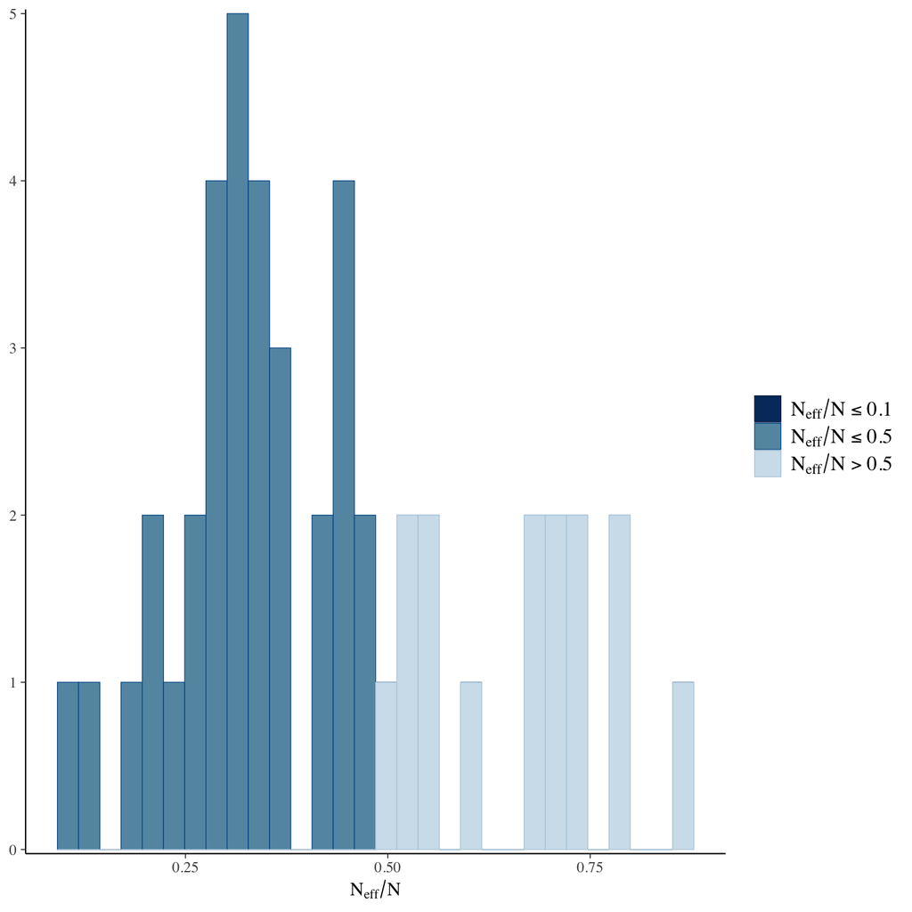

```r
# plot(full.mod) # this will spit out density and trace plots for all parameters! we will do it separately.

mcmc_plot(full.mod, type="neff_hist")    # effective sample size
```

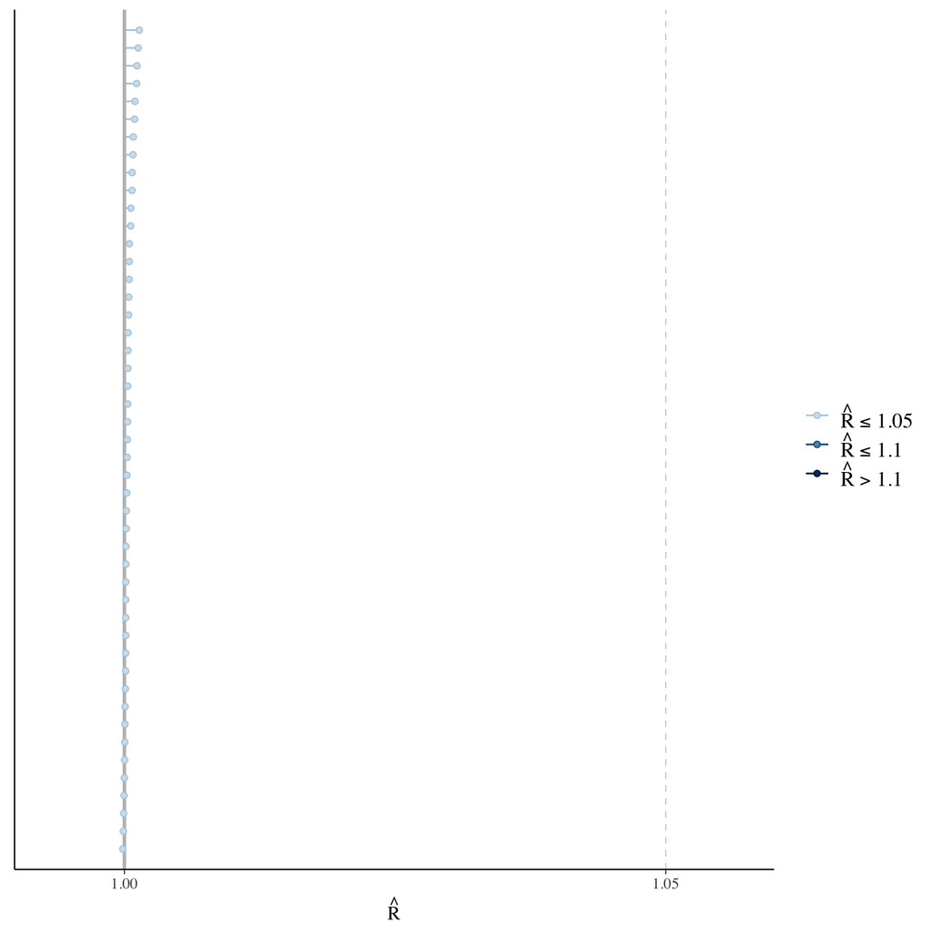

```r
# ratio: Neff/N -> closer to 1 is better (lighter); light: between 0.5 and 1 (high); mid: between 0.1 and 0.5 (good); dark: below 0.1 (low)

mcmc_plot(full.mod, type="rhat")         # R hat (~1)
```

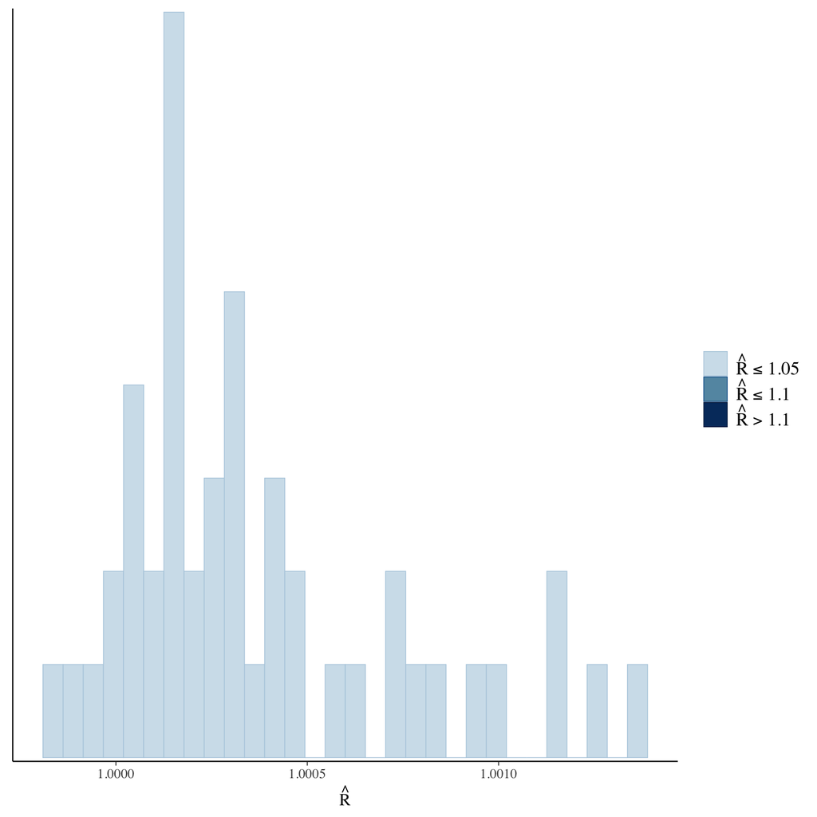

```r
mcmc_plot(full.mod, type="rhat_hist")    # R hat (~1)
```

```r
# pull out specific rhat estimates of interest
head(rhat(full.mod))
```

```
##      b_Intercept   b_periodwinter    b_periodz_den         b_cover1
##         1.000340         1.000181         1.001173         1.001134
## b_high_temp_mean   b_days_elapsed
##         1.000409         1.000128
```

```
## No divergences to plot.
```

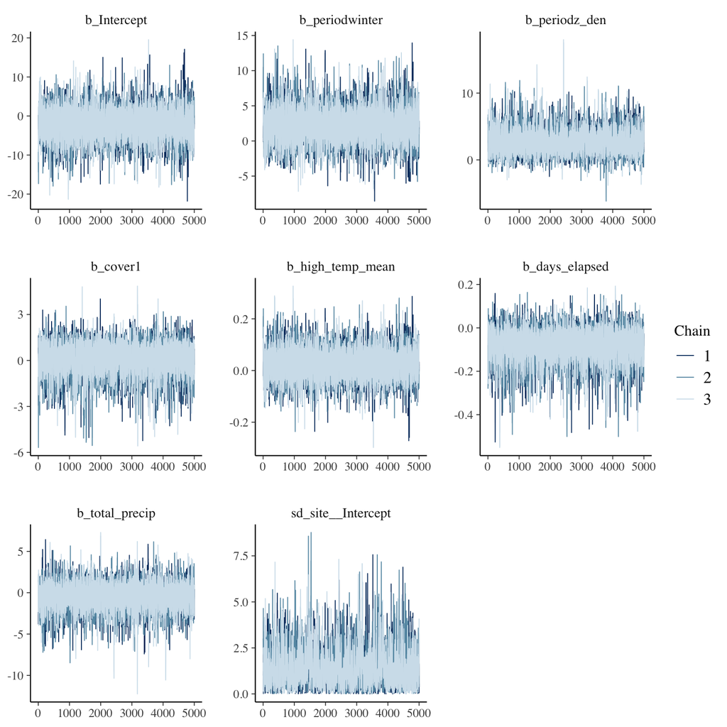

```r
mcmc_plot(full.mod, type="trace")        # trace plots
```

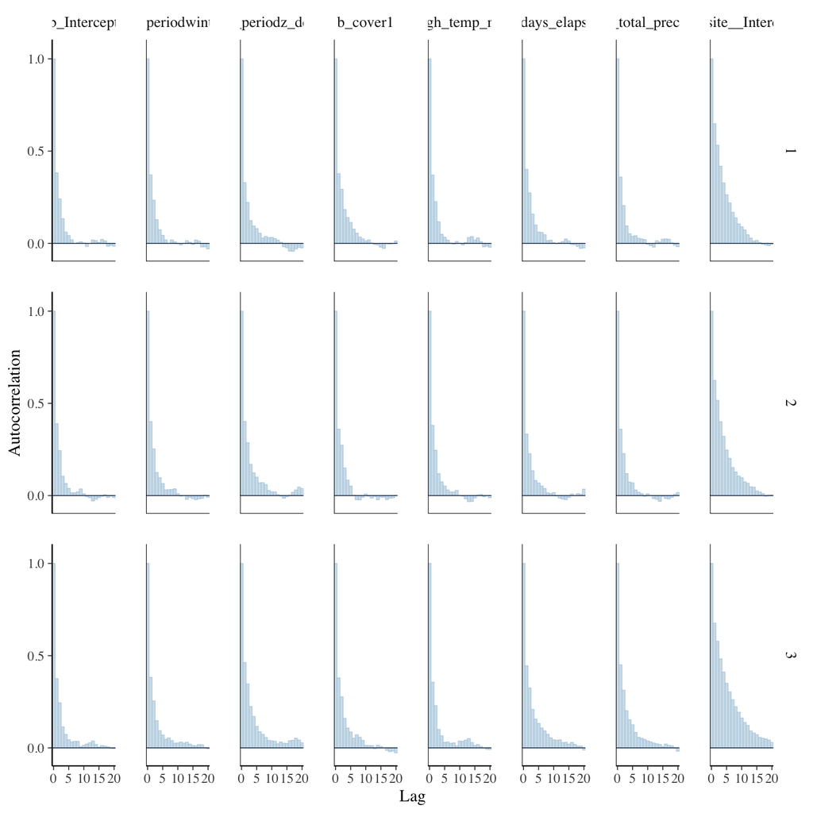

```r
mcmc_plot(full.mod, type="acf_bar")      # look at autocorrelation
```

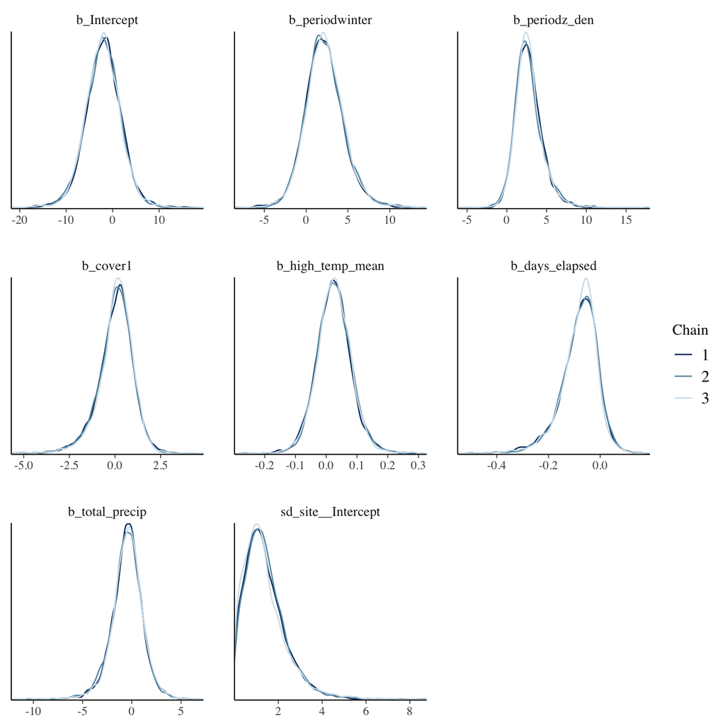

```r
mcmc_plot(full.mod, type="dens_overlay") # density plots for each chain
```

There are even more types of convergence plots we could look at with **brms**! But these are the main ones.

# Posterior summaries

The plots below have other specifics you can add, like labels, etc.

```r
# pull out the posterior samples
posterior <- as.array(full.mod)
dim(posterior)
```

```
## [1] 5000    3   47
```

```r
# number of iterations retained, number of chains, number of parameters:
dimnames(posterior)
```

```
## $iterations
## NULL
##
## $chains
## [1] "chain:1" "chain:2" "chain:3"
##
## $parameters
##  [1] "b_Intercept"          "b_periodwinter"       "b_periodz_den"
##  [4] "b_cover1"             "b_high_temp_mean"     "b_days_elapsed"
##  [7] "b_total_precip"       "sd_site__Intercept"   "r_site[1,Intercept]"
## [10] "r_site[2,Intercept]"  "r_site[3,Intercept]"  "r_site[4,Intercept]"
## [13] "r_site[5,Intercept]"  "r_site[6,Intercept]"  "r_site[8,Intercept]"
## [16] "r_site[9,Intercept]"  "r_site[10,Intercept]" "r_site[11,Intercept]"
## [19] "r_site[12,Intercept]" "r_site[13,Intercept]" "r_site[14,Intercept]"
## [22] "r_site[17,Intercept]" "r_site[18,Intercept]" "r_site[20,Intercept]"
## [25] "r_site[21,Intercept]" "r_site[24,Intercept]" "r_site[26,Intercept]"
## [28] "r_site[31,Intercept]" "r_site[32,Intercept]" "r_site[33,Intercept]"
## [31] "r_site[36,Intercept]" "r_site[37,Intercept]" "r_site[40,Intercept]"
## [34] "r_site[42,Intercept]" "r_site[43,Intercept]" "r_site[44,Intercept]"
## [37] "r_site[45,Intercept]" "r_site[46,Intercept]" "r_site[47,Intercept]"
## [40] "r_site[48,Intercept]" "r_site[64,Intercept]" "r_site[65,Intercept]"
## [43] "r_site[66,Intercept]" "r_site[67,Intercept]" "r_site[68,Intercept]"
## [46] "r_site[69,Intercept]" "lp__"
```

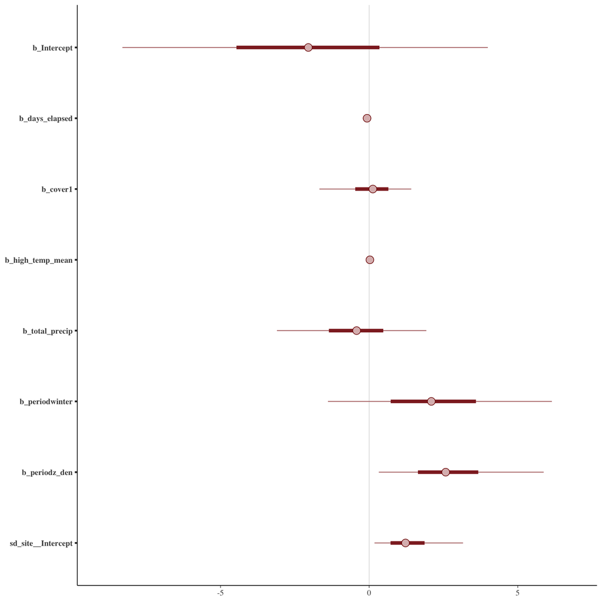

```r
color_scheme_set("red") # pick the color you want for the automated plots, default is blue
# line plots
mcmc_intervals(posterior, pars=c("b_Intercept","b_days_elapsed","b_cover1","b_high_temp_mean","b_total_precip","b_periodwinter","b_periodz_den","sd_site__Intercept"))
```

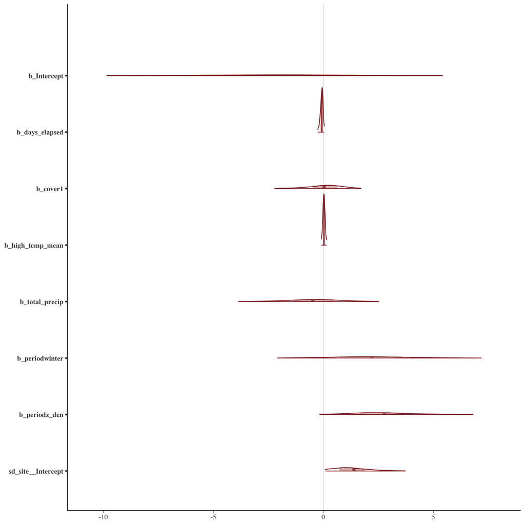

```r
# density plots
mcmc_areas(
  posterior,
  pars=c("b_Intercept","b_days_elapsed","b_cover1","b_high_temp_mean","b_total_precip","b_periodwinter","b_periodz_den","sd_site__Intercept"),
  prob=0.5, # 50% intervals
  prob_outer=0.95, # 95%  intervals
  point_est="mean"
)
```

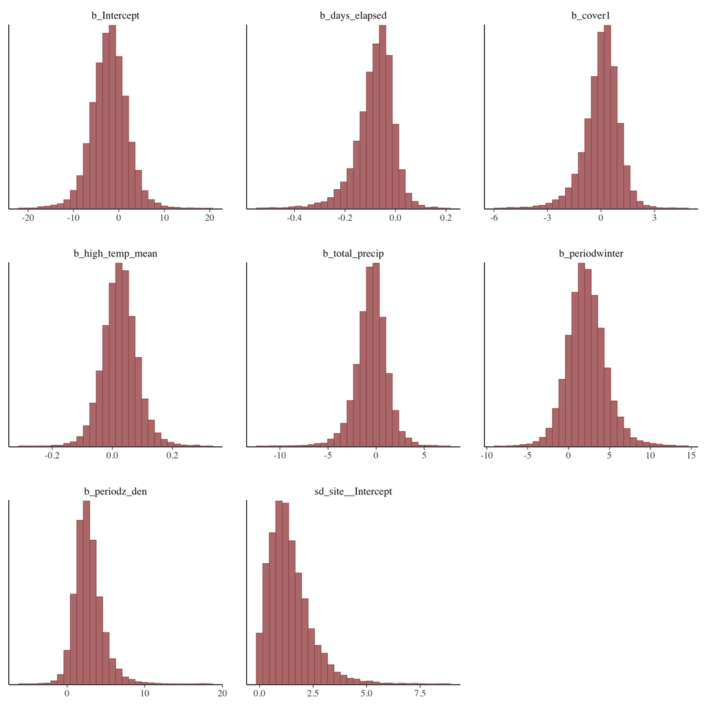

```r
# histograms
mcmc_hist(posterior, pars=c("b_Intercept","b_days_elapsed","b_cover1","b_high_temp_mean","b_total_precip","b_periodwinter","b_periodz_den","sd_site__Intercept"))
```

We can also make manual plots of posterior estimates with density shading:

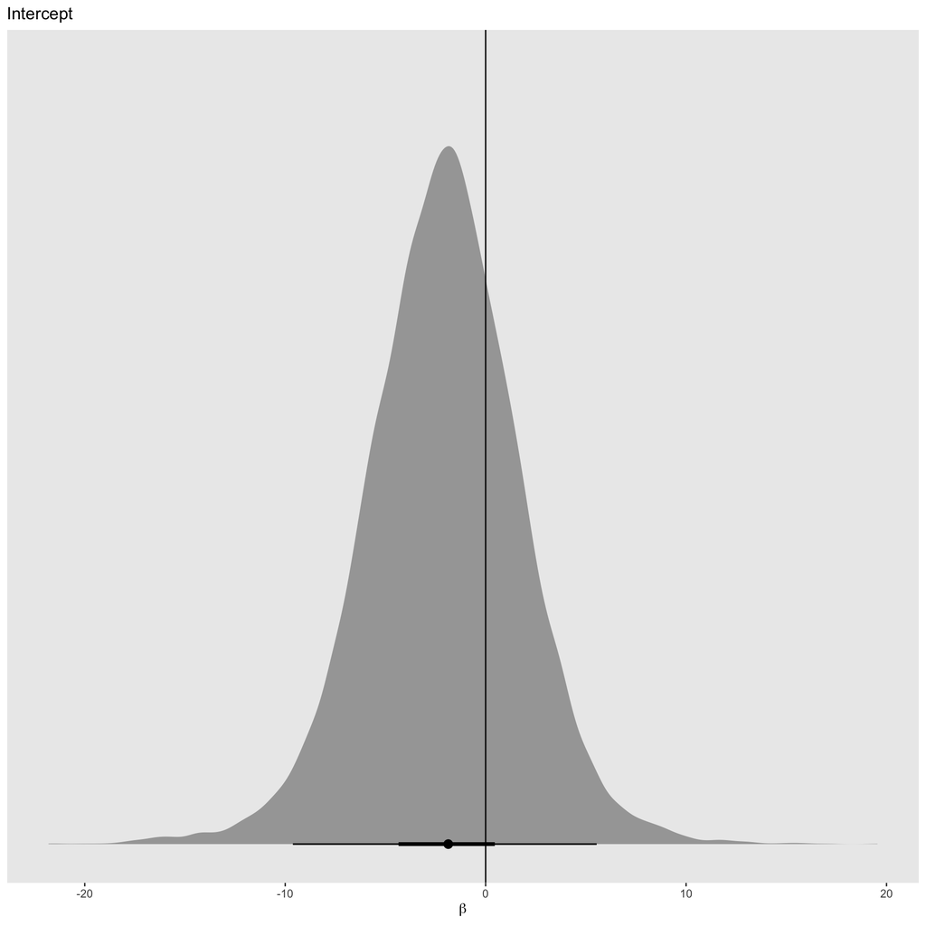

```r
post <- posterior_samples(full.mod, add_chain=T) # get posterior in usable form

# intercept
ggplot(post, aes(x=b_Intercept, y=0)) +
  stat_halfeye(point_interval=mode_hdi, .width=c(.95, .5)) +
  scale_y_continuous(NULL, breaks=NULL) +
  labs(title="Intercept",
       x    =expression(beta)) +
  theme(panel.grid=element_blank()) +
  vline_0()
```

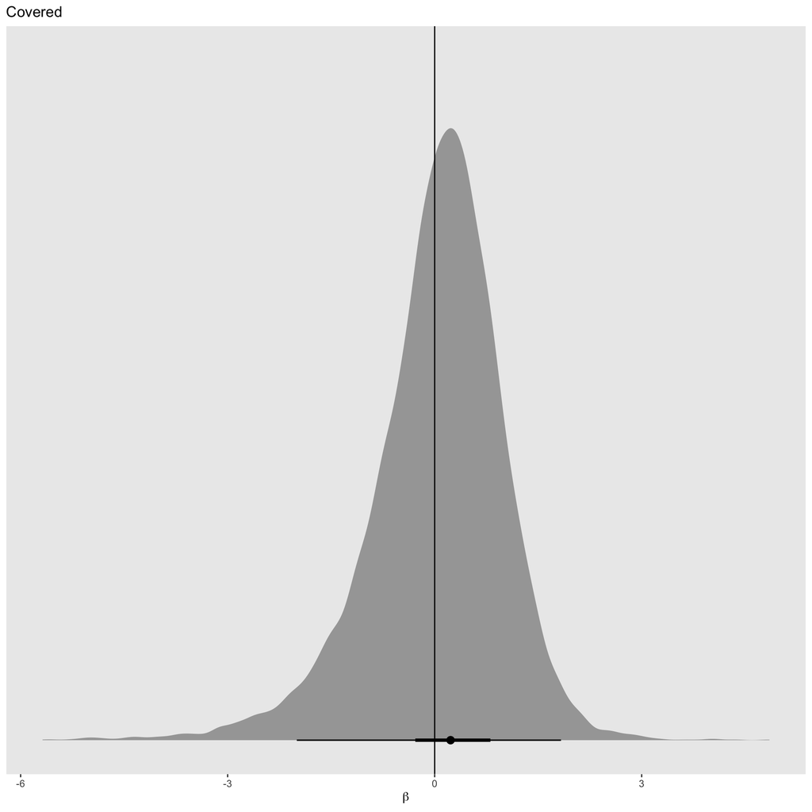

```r
# UV radiation: open/covered
ggplot(post, aes(x=b_cover1, y=0)) +
  stat_halfeye(point_interval=mode_hdi, .width=c(.95, .5)) +
  scale_y_continuous(NULL, breaks=NULL) +
  labs(title="Covered",
       x    =expression(beta)) +
  theme(panel.grid=element_blank()) +
  vline_0()
```

## Exponentiating

Since this is a logit model, we may want to exponentiate the coefficients. This is easy with the ‘transformations=“exp”’ line:

```r
exp(fixef(full.mod))
```

```
##                  Estimate Est.Error         Q2.5       Q97.5
## Intercept       0.1239540 47.389089 5.294899e-05  224.426454
## periodwinter    9.0636733 10.312207 1.237337e-01 1308.762621
## periodz_den    15.9547412  5.800901 8.444815e-01  895.182753
## cover1          1.0316789  2.643550 1.096665e-01    5.484713
## high_temp_mean  1.0254931  1.057926 9.195041e-01    1.149726
## days_elapsed    0.9221901  1.076573 7.738724e-01    1.039185
## total_precip    0.6150380  4.887916 2.098864e-02   12.426977
```

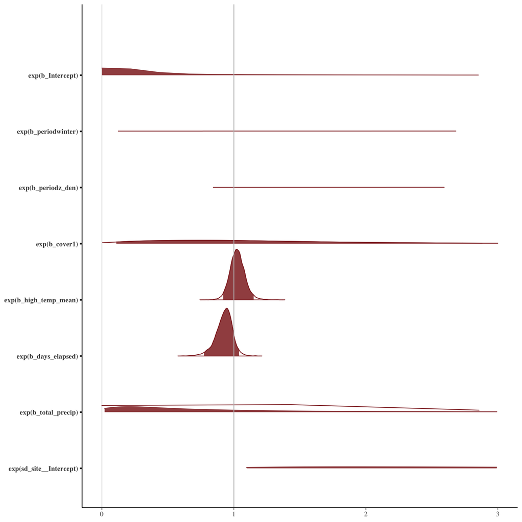

```r
mcmc_plot(full.mod,
         type="areas",
         prob=0.95,
         transformations="exp") +
  geom_vline(xintercept=1, color="grey") +
  xlim(0,3)
```